# HW 2: Visualization, Base R

## Task 3

1. What is the type of variable `Passengers`? (Categorical nominal/ordinal or Numerical discrete/continuous?) What happens if we were to make a histogram for `Passengers`? What is the problem with this graph?

```r
class(Cars93$Passengers) # this is an integer
```

```
## [1] "integer"
```

```r
# this is numerical discrete because it is numerical/finite and can be counted.
# the problem with this is that histograms are only for continuous data. We need to transform this into a barplot.

Cars93$Passengers
```

```
##  [1] 5 5 5 6 4 6 6 6 5 6 5 5 5 4 6 7 8 6 2 6 6 6 5 5 6 7 6 4 5 6 4 5 5 4 4 7 5 6
## [39] 4 4 4 4 4 5 5 4 5 5 5 4 6 6 4 5 5 7 2 5 5 4 5 5 5 5 5 7 5 5 5 7 6 4 4 5 4 5
## [77] 6 5 5 4 5 5 4 5 4 5 7 4 7 5 4 5 5
```

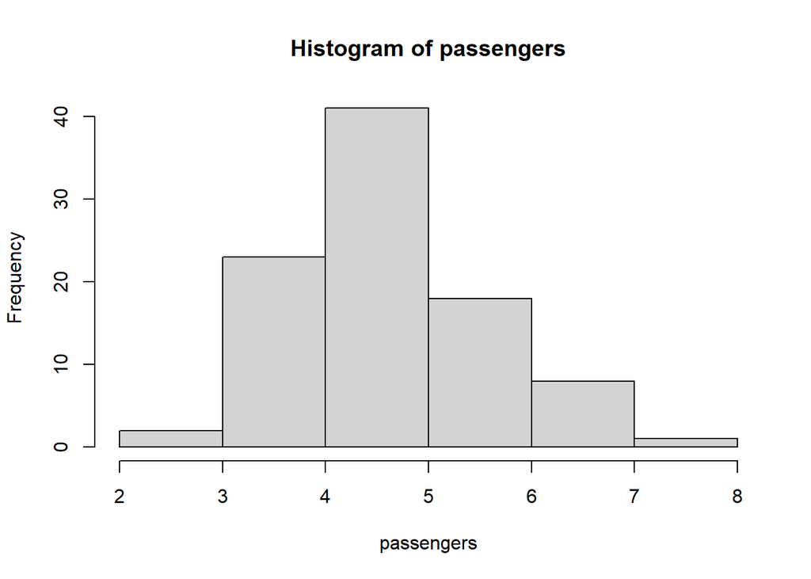

```r
passengers = c(Cars93$Passengers)
hist(passengers,
     main = "Passengers Histogram",
     xlab = "Passengers",
     ylab = "Frequency",
     col = "red",
     border = "black",
     breaks = 15,
     xlim = range(passengers),
     ylim = c(0, max(hist(passengers)$counts) + 1),
     labels = TRUE)
```

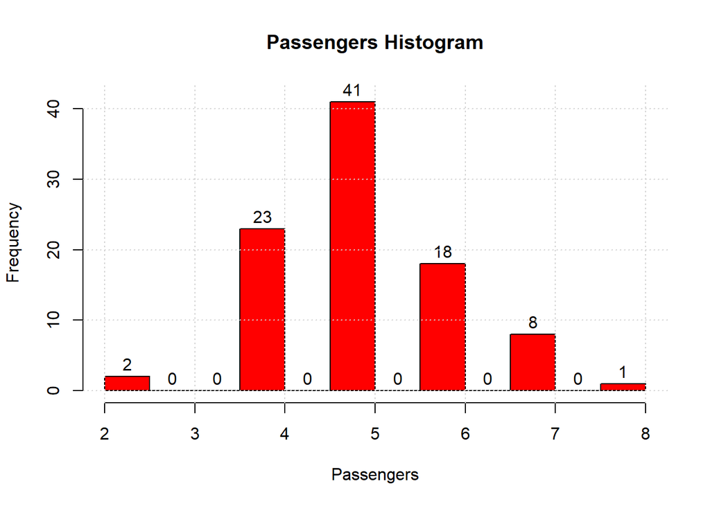

```r
par(cex.axis = 1.2, cex.lab = 1.2)
grid()
```

2. Correct the problem in part (a) by creating a more appropriate visualization. Make sure to label your axes, place a title, choose a custom color as in the previous graphs. (Bonus: use factor() with levels option to display x axis values with no observations on the plot.)

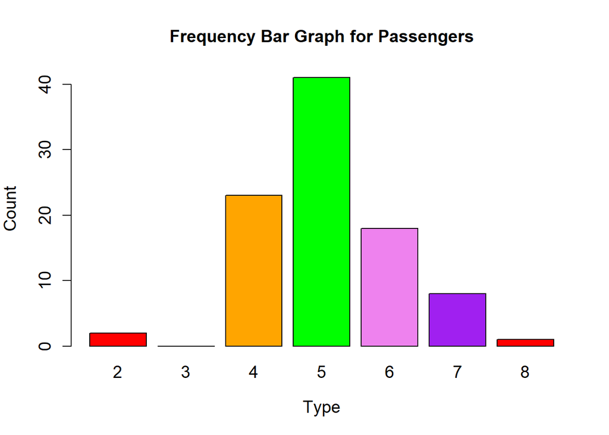

```r
passengers = c(Cars93$Passengers)
freq_table = table(factor(passengers, levels = c("2","3","4","5","6","7","8")))
colors = c("red","blue","orange","green","violet","purple")
barplot(freq_table,
        main = "Frequency Bar Graph for Passengers",
        xlab = "Type",
        ylab = "Count",
        col = colors,
        border = "black",
        ylim = c(0, max(freq_table) + 1),
        names.arg = names(freq_table),
        cex.names = 1.2,
        cex.axis = 1.2,
        cex.lab = 1.2)
```

```r
print(freq_table)
```

```
##
##  2  3  4  5  6  7  8
##  2  0 23 41 18  8  1
```

## Task 4

1. Make a histogram of the variable `Length` (the default breaks are fine). Other aspects of the plot should be as in part (a) in Task 2.

```r
Cars93$Length
```

```
##  [1] 177 195 180 193 186 189 200 216 198 206 204 182 184 193 198 178 194 214 179
## [20] 203 183 203 174 172 181 175 192 180 174 202 141 171 177 180 179 176 192 212
## [39] 151 164 175 173 185 168 172 166 184 200 188 191 205 219 164 172 184 190 169
## [58] 175 187 166 199 172 190 170 181 190 188 188 190 194 201 173 177 181 196 195
## [77] 177 184 176 146 175 179 161 162 174 188 187 163 187 180 159 190 184
```

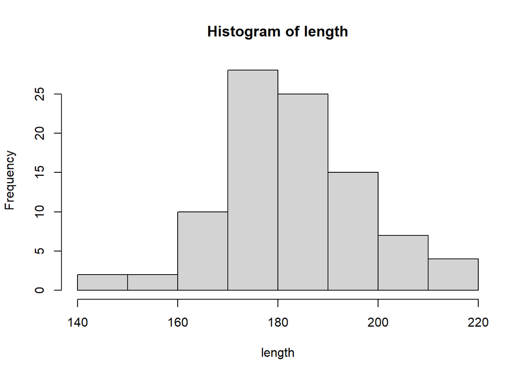

```r
length = c(Cars93$Length)
hist(length,
     main = "Length Histogram",
     xlab = "Length",
     ylab = "Frequency",
     col = "red",
     border = "black",
     breaks = 50,
     xlim = range(length),
     ylim = c(0, max(hist(length)$counts) + 1),
     labels = TRUE)
```

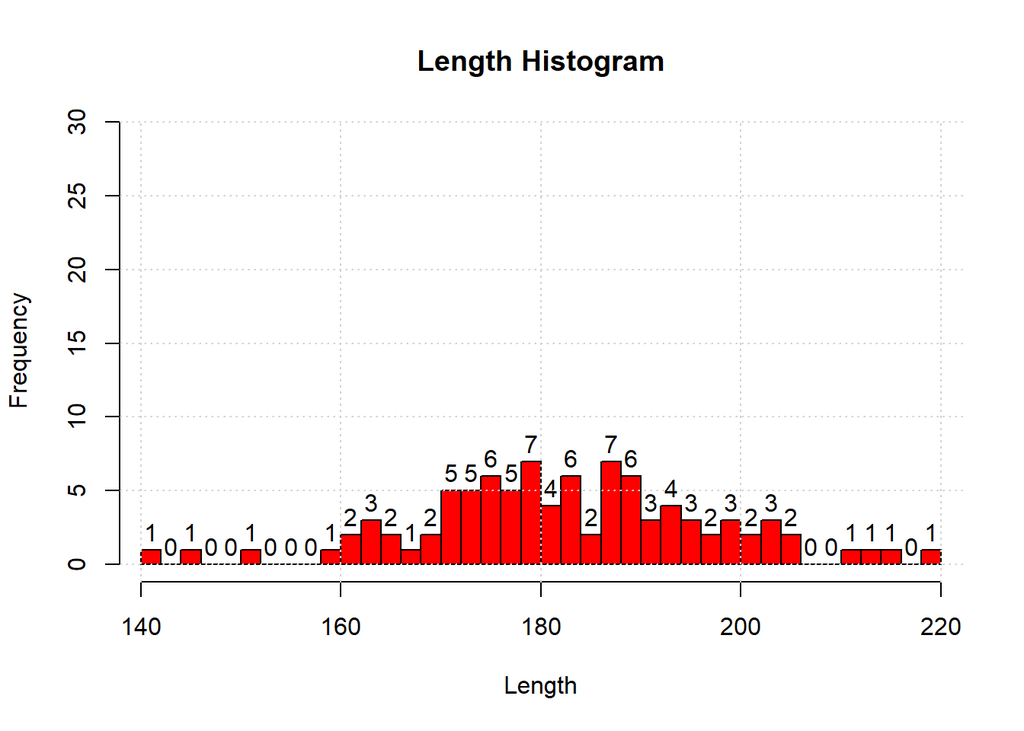

```r
par(cex.axis = 1.2, cex.lab = 1.2)
grid()
```

2. What is the shape of the distribution? The distribution is bell shaped.
3. Find the mean and median of the variable `Length.` Do these answers meet your expectations from part (b)?

```r
length = c(Cars93$Length)
mean_len = mean(length)
median_len = median(length)
print(mean_len)
```

```
## [1] 183.2043
```

```r
print(median_len)
```

```
## [1] 183
```

```r
# yes because it is bell shaped so the mean, median, and mode will all be similar. (normal distribution)
```

You are done! 🏁 Don’t forget to commit and push your .Rmd file to your Github repository before the due date.